# Exploratory Data Analysis - Project DeepPlay

Fabien Plisson

2/2/2017

1. Set directory and Import libraries

```r
library(ggplot2)
library(data.table)
library(reshape)
```

2. Load datasets

```r
cnf <- read.csv("scraped_data/results_cnf.csv", header=TRUE)
```

3. Data Analysis For each discipline (except STA), convert all depth results as negative values and make sure dates of each event in converted into a date format.

Function depth_and_date(df)

```r
depth_and_date <- function(df){
  df$Result_m <- -abs(df$Result_m)
  df$Announced <- -abs(df$Announced)
  df$Date <- as.Date(factor(df$Date), format = "%Y-%m-%d")
  return(df)
  }
```

Example: CNF - constant no fins.

```r
cnf <- depth_and_date(cnf)
head(cnf, 10)
```

```
##    Ranking               Name Result_m Announced Points Penalties
## 1        1 William TRUBRIDGE      -102      -102    102         0
## 2        2 William TRUBRIDGE      -102      -102    102         0
## 3        3 William TRUBRIDGE      -101      -101    101         0
## 4        4 William TRUBRIDGE      -100      -100    100         0
## 5        5 William TRUBRIDGE      -100      -100    100         0
## 6        6 William TRUBRIDGE       -98       -98     98         0
## 7        7 William TRUBRIDGE       -97       -97     97         0
## 8        8 William TRUBRIDGE       -97       -97     97         0
## 9        9 William TRUBRIDGE       -97       -97     97         0
## 10      10 William TRUBRIDGE       -97       -97     97         0
##          Date                                    Place     Country
## 1  2016-07-14 World Record Attempt - William Trubridge New Zealand
## 2  2016-07-14 World Record Attempt - William Trubridge New Zealand
## 3  2010-12-11     WR Attempt - TRUBRIDGE William (CNF) New Zealand
## 4  2016-05-26                       Caribbean Cup 2016 New Zealand
## 5  2010-12-11     WR Attempt - TRUBRIDGE William (CNF) New Zealand
## 6  2015-06-06                       NIRVANA OCEANQUEST New Zealand
## 7  2012-11-20                Suunto Vertical Blue 2012 New Zealand
## 8  2012-11-20                Suunto Vertical Blue 2012 New Zealand
## 9  2012-11-20                Suunto Vertical Blue 2012 New Zealand
## 10 2014-05-25                       Caribbean Cup 2014 New Zealand
```

Feature engineering: determining the earliest and latest dates as well as minimal and maximal depths for each athlete. The function creates all new data into a new dataframe.

Function min_and_max(df)

```r
min_and_max <- function(df){
  dt <- data.table(df)
  tmin <- dt[ , list(MinDate = min(Date)), by = Name]
  tmax <- dt[ , list(MaxDate = max(Date)), by = Name]
  dmin <- dt[ , list(MinDepth = max(Result_m)), by = Name]
  dmax <- dt[ , list(MaxDepth = min(Result_m)), by = Name]
  merge1 <- merge(tmin,tmax,by="Name")
  merge2 <- merge(dmin,dmax,by="Name")
  new_df <- merge(merge1, merge2,by="Name")
  return(new_df)
}
```

```r
new_cnf <- min_and_max(cnf)
head(new_cnf, 10)
```

```
##                                     Name    MinDate    MaxDate MinDepth
##  1:            Abundio RONQUILLO MIGUEL  2008-06-20 2008-06-20        0
##  2:                          Adam STERN  2013-08-24 2015-06-06      -45
##  3:                     Adel Abu HALIQA  2009-06-22 2010-06-14      -21
##  4:                  Adrian KWIATKOWSKI  2010-08-01 2010-08-01      -31
##  5:                       Adrian SUAREZ  2007-10-27 2009-12-03      -32
##  6:                       ADRIANA BANTU  2014-06-29 2014-06-29      -23
##  7: Adriana Buechner de Freitas Brandao  2012-11-20 2014-05-11      -35
##  8:         Adriana Gabriela BANTU-DINU  2014-08-21 2014-10-05      -28
##  9:                       Adrien TALBOT  2007-08-14 2007-08-14      -43
## 10:                        Agata Bogusz  2009-09-06 2016-04-30      -36
##     MaxDepth
##  1:        0
##  2:      -58
##  3:      -27
##  4:      -31
##  5:      -44
##  6:      -23
##  7:      -36
##  8:      -30
##  9:      -47
## 10:      -43
```

Measure time difference with function time_difference(new_df):

```r
time_difference <- function(new_df){
  start <- c(new_df$MinDate)
  end <- c(new_df$MaxDate)
  new_df$diffDate <- difftime(end, start, units = "days")
  return(new_df)
}
```

```r
new_cnf <- time_difference(new_cnf)
head(new_cnf, 10)
```

```
##                                     Name    MinDate    MaxDate MinDepth
##  1:            Abundio RONQUILLO MIGUEL  2008-06-20 2008-06-20        0
##  2:                          Adam STERN  2013-08-24 2015-06-06      -45
##  3:                     Adel Abu HALIQA  2009-06-22 2010-06-14      -21
##  4:                  Adrian KWIATKOWSKI  2010-08-01 2010-08-01      -31
##  5:                       Adrian SUAREZ  2007-10-27 2009-12-03      -32
##  6:                       ADRIANA BANTU  2014-06-29 2014-06-29      -23
##  7: Adriana Buechner de Freitas Brandao  2012-11-20 2014-05-11      -35
##  8:         Adriana Gabriela BANTU-DINU  2014-08-21 2014-10-05      -28
##  9:                       Adrien TALBOT  2007-08-14 2007-08-14      -43
## 10:                        Agata Bogusz  2009-09-06 2016-04-30      -36
##     MaxDepth  diffDate
##  1:        0    0 days
##  2:      -58  651 days
##  3:      -27  357 days
##  4:      -31    0 days
##  5:      -44  768 days
##  6:      -23    0 days
##  7:      -36  537 days
##  8:      -30   45 days
##  9:      -47    0 days
## 10:      -43 2428 days
```

# Q: Which athlete has the longest career in competitive freediving?

Function longest_career(new_df)

```r
longest_career <- function(new_df){
  new_df <- new_df[order(MinDate),]
  new_df$Name <- reorder(new_df$Name, new_df$MinDate)

  # Use name of data.frame as a string to insert in title (pdf)
  #df_name <- toString(deparse(substitute(new_df))) Working
  #But title substitution is not working with paste/paste0/stringf... "error: pdf title too long"
  #title <- paste(format("Longest_career_", names(df_name)[1], ".pdf"))

  pdf("Longest_career.pdf", width=20, height=18)
  p <- ggplot(subset(new_df, diffDate > 2200), aes(y = Name)) +
    labs(x = "", y = "Athlete") +
    geom_segment(aes(x = MinDate, y = Name, xend = MaxDate, yend = Name), size = 1) +
    geom_point(aes(x = MinDate, color = "MinDate"), size = 4, shape = 15) +
    geom_point(aes(x = MaxDate, color = "MaxDate"), size = 4, shape = 15) +
    scale_color_discrete(name = "Time (years)") +
    theme_bw() +
    theme(legend.position = "bottom")

  print(p)
  dev.off();
}
```

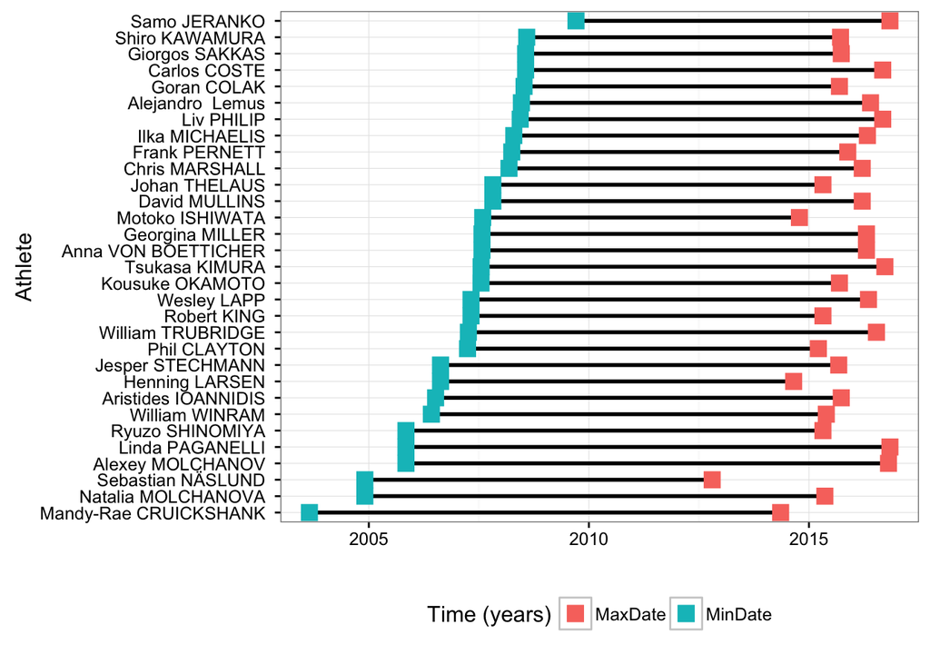

```r
longest_career(new_cnf)
```

# Q: Which countries (national record) are leading the competition over time?

Displaying national records (maximal depth regardless of the athlete name) over time in a specific discipline. Apply function depth_and_date() with original dataset e.g. cnf prior to use leaderboard().

```r
leaderboard <- function(df){
  df$Year <- year(df$Date)
  df_agg <- aggregate(Result_m ~ Year + Country, data = df, min)
  df_agg2 <- cnf_agg[order(df_agg$Result_m),]
  df_agg2$Country <- reorder(df_agg2$Country, df_agg2$Result_m)
  return(df)

  pdf("Timeline_Country_Depth.pdf")
  p <- ggplot(cnf_agg2, aes(Year, Result_m, group=Country, color=Country)) +
    geom_line(linetype = 2, size=0.25) +
    geom_point() +
    scale_color_discrete(name = "Time (years)", guide = FALSE) +
    theme_bw() +
    ylab("Depth (m)")

  print(p)
  dev.off()
}
```

```r
#leaderboard(cnf)
```

[figure not shown]

# Future Steps

- Building Interactive plots using r/Bokeh and D3.js,
- Adding new features using web_scraping, predictive analysis (gender, lat/long, water temp.),
- Creating a new website.